# Cross-linguistic analysis of converbs: Semantic maps and parallel data for a better understanding of adverbial subordination in European languages

Initial dissimilarity analysis of syntactic forms

Published

2026-06-07, 20:45

# Spanish

## Output files

This report generates a set of files. Each run produces its own files in a new subfolder. The subfolder is named with the target language and a random sequence of five characters (capital letters and digits). The names of all files within this subfolder are prefixed with the subfolder’s name. For this run, the output file sequence is Spanish-XE8N2_ .

## Research question

- Record equivalent verb forms in the other languages.
- Use Multidimensional Scaling to create a two-dimensional space with the forms in the target language (Spanish), considering the syntactic forms of the equivalents in other languages. We adopt a Translation Mining script by Bert Le Bruyn (Le Bruyn et al. 2022).
- Examine the distribution of participles vs. gerunds in that space. When they separate into clusters, they are not interchangeable in Spanish.

**CautionCustomized workflow**

## Input

### Ex post corrections of input data

```r
# pozor, tady se sloupce nenahrazuji parametry, protoze jde o jazykove specificke upravy
df$form.fr[df$form.fr == "adn"] <- "part" # dodatecna oprava vstupnich dat, mozna nebude potreba v dalsi verzi
```

XLSX file with the following columns: ID_occurrence, src.lang, fr1, KWIC.fr, fr2, lemma.fr, meaning.fr, es, form.fr, form.cs, form.en, form.es, form.it, form.pl, form.ru.

Each row represents one sentence, where the French version uses either a participle or a gerund in the adverbial position.

The dataset is being continuously updated and may be incomplete at the time when this script is being executed. Therefore we always filter away incomplete observations; that is, we keep only rows that contain form labels for all investigated languages.

The current dataset has 364 observations (136 were filtered away as incomplete.)

## Multidimensional Scaling

### MDS with *form.*<language> as factors

Le Bruyn’s function for [multidimensional scaling](https://www.geeksforgeeks.org/data-analysis/what-is-multidimensional-scaling/) ([Hamming distance](https://www.datacamp.com/tutorial/hamming-distance) normalized to [0,1], two dimensions), slightly adapted and commented by us.

On input it requires a data frame containing just the “factors”, i.e. the *form.language* columns with the labels for the observed verb form in each language for the given item, and a vector of IDs. This vector actually corresponds to the ID_occurrence column in our input data frame.

```r
custom_dissimilarity <- function(data, id_colname){
  n <- nrow(data)
  k <- ncol(data)
  dist_matrix <- matrix(0,n,n) # an empty matrix (full of zeros)
  for (i in 1:n) {
    for (j in 1:n) {
      diff_count <- sum(data[i, ] != data[j, ])
      dist_matrix[i, j] <- diff_count / k  }  }
  dist_df <- as.data.frame(dist_matrix)
  rownames(dist_df) <- df[[id_colname]]
  colnames(dist_df) <- df[[id_colname]]
  return(dist_df)}
```

```r
df_factors <- df %>%
  select(c(matches(regex("^form\\.(?!fr)"))))

dissimilarity_matrix <- custom_dissimilarity(data = df_factors,
                                             id_colname = params$row_id_column)
write_csv2(dissimilarity_matrix,
           file = str_c(outputfile_prefix,
                        "/",
                        outputfile_prefix,
                        "_distance_matrix.csv"),
           col_names = FALSE)
```

```r
dist_matrix <- dissimilarity_matrix
dist_matrix <- dist_matrix
dist_object <- as.dist(dist_matrix)
mds_result <- cmdscale(dist_object, k = 2)
write.csv2(mds_result, file = str_c(outputfile_prefix,
                        "/",
                        outputfile_prefix,"_mds_result.csv"))
```

All analytical tables are saved in the folder Spanish-XE8N2_, along with the static plot below.

### Semantic map (*form.*<language> as factors)

This plot shows each observation point

We use two color scales to contrast:

1. the Spanish form (Column form.es)
2. the source language of each item.

The numbers represent the IDs of the items and are slightly nudged from the points. When points overlap, their ID labels point to the same position.

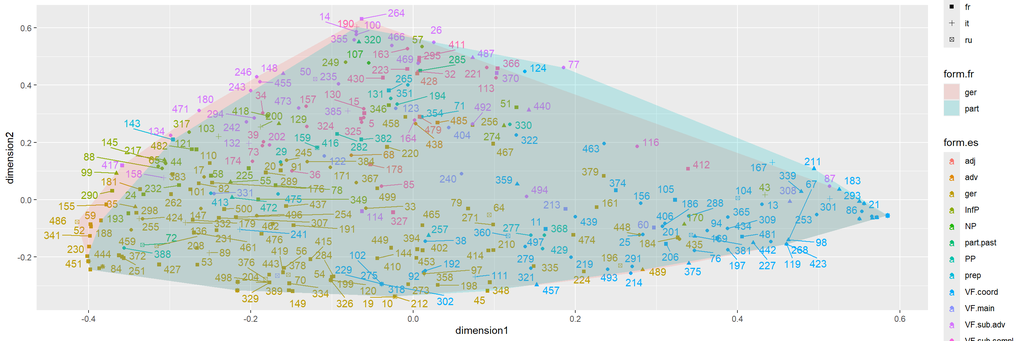

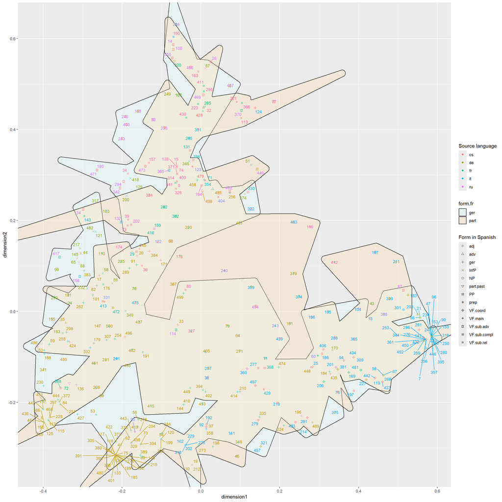

```
[[1]]
[1] "Spanish-XE8N2_/Spanish-XE8N2__semantic_map_plot.png"

[[2]]
[1] "Spanish-XE8N2_/Spanish-XE8N2__semantic_map_plot.pdf"

[[3]]
[1] "Spanish-XE8N2_/Spanish-XE8N2__semantic_map_plot.svg"
```

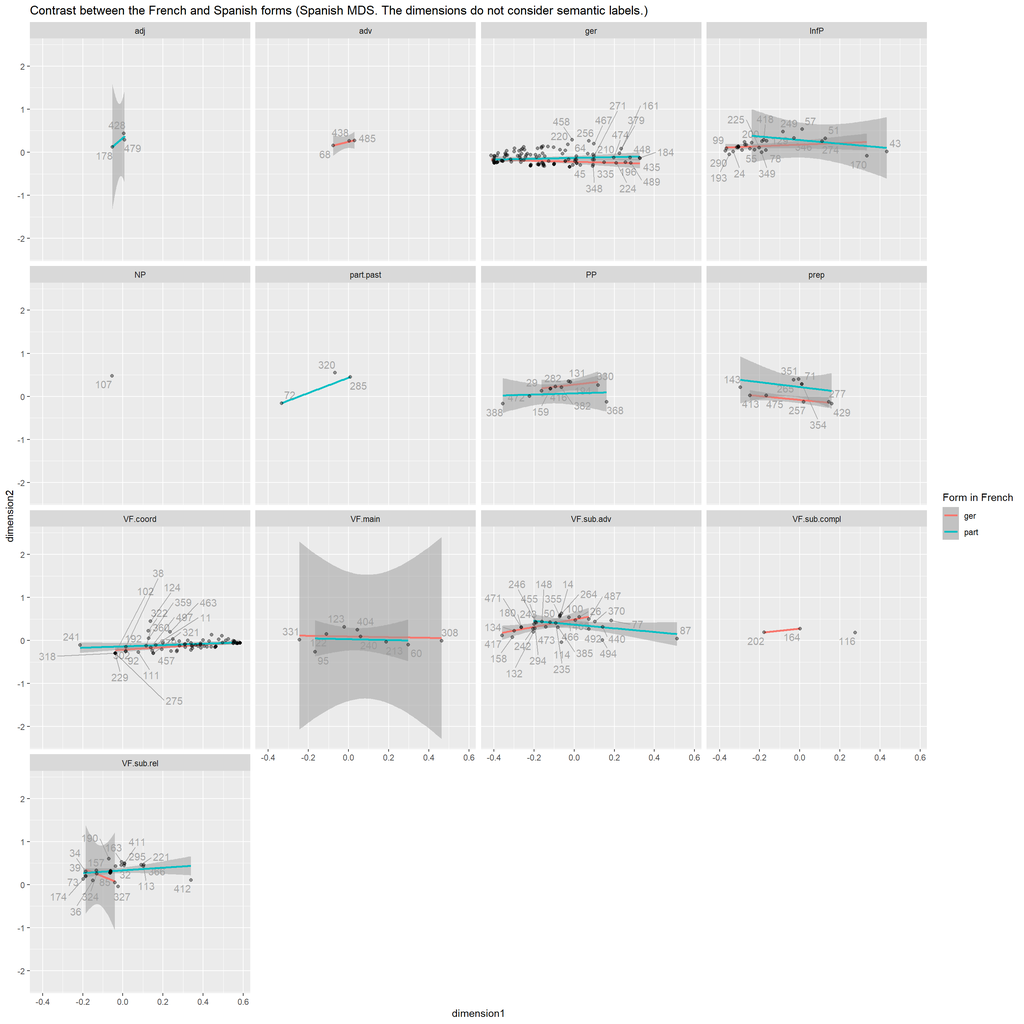

```
[[1]]
[1] "Spanish-XE8N2_/Spanish-XE8N2__semantic_map_LM_plot.png"

[[2]]
[1] "Spanish-XE8N2_/Spanish-XE8N2__semantic_map_LM_plot.pdf"

[[3]]
[1] "Spanish-XE8N2_/Spanish-XE8N2__semantic_map_LM_plot.svg"
```

### Interactive plots (*form.*<language> as factors)

These plots are only visible in documents rendered as html.

#### Documents in the target language, by their individual source languages

Hover your mouse over a point to see the text ID, semantic label, and concordance.

[interactive chart not shown]

Documents in the target language, by their individual source languages

#### All documents together

[interactive chart not shown]

All source languages included.

#### Just documents with French as source language

[interactive chart not shown]

Exclusively documents with source language French

### MDS with *meaning.fr* and *form*.<language> as factors

```r
df_factors_frmeaning <- df %>%
  #select(c(matches("^form\\."), meaning.fr))
  select(c(matches(regex("^form\\.(?!fr)")), meaning.fr))

dissimilarity_matrix_frmeaning <- custom_dissimilarity(data = df_factors_frmeaning,                                           id_colname = params$row_id_column)
write_csv2(dissimilarity_matrix_frmeaning,
           file = str_c(outputfile_prefix,
                        "/",
                        outputfile_prefix,
                        "_distance_matrix_frmeaning.csv"),
           col_names = FALSE)
```

```r
dist_matrix_frmeaning <- dissimilarity_matrix_frmeaning
#dist_matrix <- dist_matrix
dist_object_frmeaning <- as.dist(dist_matrix_frmeaning)
mds_result_frmeaning <- cmdscale(dist_object_frmeaning, k = 2)
write.csv2(mds_result_frmeaning, file = str_c(outputfile_prefix,
                        "/",
                        outputfile_prefix,"_mds_result_frmeaning.csv"))
```

All analytical tables are saved in the folder Spanish-XE8N2_, along with the static plot below.

### Semantic map (*form.*<language> and *meaning.fr* as factors)

This plot shows each observation point

We use two color scales to contrast:

1. the Spanish form (Column form.es)
2. the source language of each item.

The numbers represent the IDs of the items and are slightly nudged from the points. When points overlap, their ID labels point to the same position.

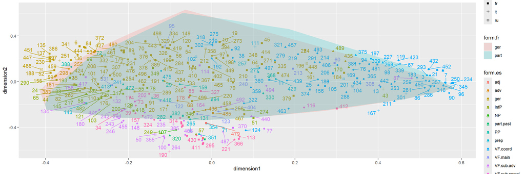

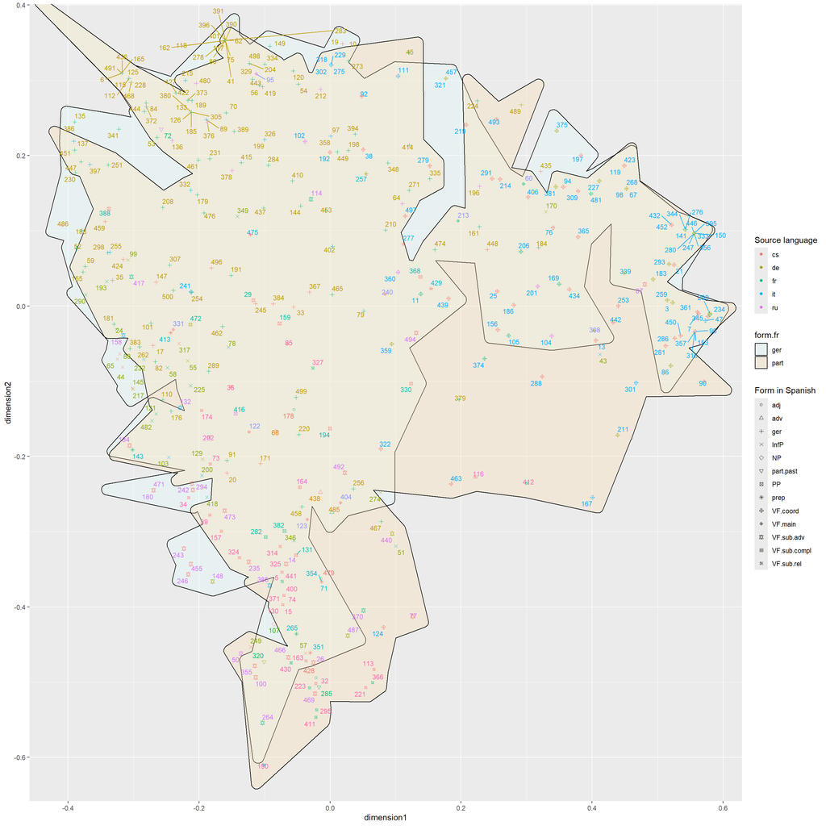

```
[[1]]
[1] "Spanish-XE8N2_/Spanish-XE8N2__semantic_map_frmeaning_plot.png"

[[2]]
[1] "Spanish-XE8N2_/Spanish-XE8N2__semantic_map_frmeaning_plot.pdf"

[[3]]
[1] "Spanish-XE8N2_/Spanish-XE8N2__semantic_map_frmeaning_plot.svg"
```

### Interactive plots (*form.*<language> and *meaning.fr* as factors)

These plots are only visible in documents rendered as html.

#### Documents in the target language, by their individual source languages

Hover your mouse over a point to see the text ID, semantic label, and concordance.

[interactive chart not shown]

Documents in the target language, by their individual source languages

#### All documents together

[interactive chart not shown]

All source languages included.

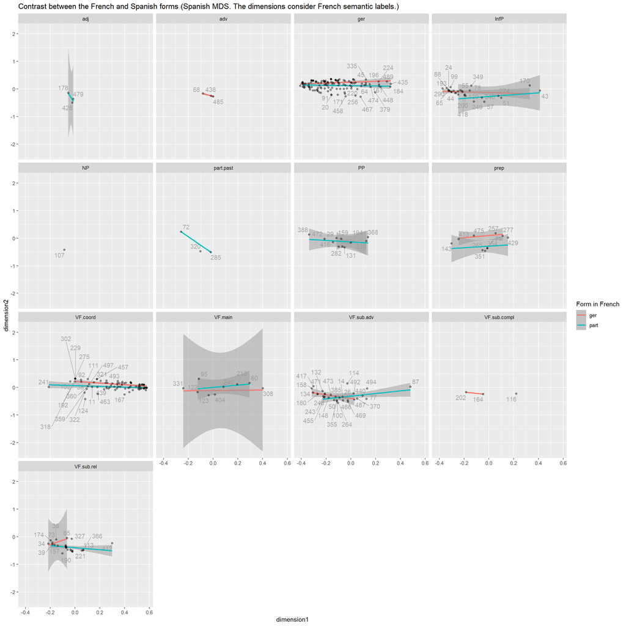

```
[[1]]
[1] "Spanish-XE8N2_/Spanish-XE8N2__LM_without_src_with_frmeaning.png"

[[2]]
[1] "Spanish-XE8N2_/Spanish-XE8N2__LM_without_src_with_frmeaning.pdf"

[[3]]
[1] "Spanish-XE8N2_/Spanish-XE8N2__LM_without_src_with_frmeaning.svg"
```

#### Just documents with French as source language

[interactive chart not shown]

Exclusively documents with source language French

## Linear regression model

```r
glm(formula = dimension2 ~ dimension1 + meaning.fr,
    data = data_frmeaning, family = "gaussian") %>%
  summary()
```

```
Call:
glm(formula = dimension2 ~ dimension1 + meaning.fr, family = "gaussian",
    data = data_frmeaning)

Coefficients:
                       Estimate Std. Error t value Pr(>|t|)
(Intercept)            -0.03062    0.05698  -0.537   0.5914
dimension1             -0.07283    0.03468  -2.100   0.0365 *
meaning.frattributive  -0.30071    0.06228  -4.829 2.06e-06 ***
meaning.frcause        -0.06430    0.06137  -1.048   0.2955
meaning.frconcess      -0.12476    0.07857  -1.588   0.1132
meaning.frconcom        0.23538    0.05888   3.998 7.81e-05 ***
meaning.frcond         -0.05831    0.17976  -0.324   0.7458
meaning.frdepictive     0.09080    0.10228   0.888   0.3753
meaning.frgram         -0.07842    0.13302  -0.590   0.5559
meaning.frmanner        0.07406    0.06194   1.196   0.2326
meaning.frposter        0.06482    0.11351   0.571   0.5684
meaning.frresult       -0.02255    0.08030  -0.281   0.7791
meaning.frsim          -0.04865    0.06224  -0.782   0.4350
meaning.frsimil/compar -0.14382    0.17943  -0.802   0.4234
---
Signif. codes:  0 '***' 0.001 '**' 0.01 '*' 0.05 '.' 0.1 ' ' 1

(Dispersion parameter for gaussian family taken to be 0.02892603)

    Null deviance: 21.342  on 363  degrees of freedom
Residual deviance: 10.124  on 350  degrees of freedom
AIC: -240.95

Number of Fisher Scoring iterations: 2
```

```
Call:
glm(formula = dimension2 ~ meaning.fr, family = "gaussian", data = data_frmeaning)

Coefficients:
                       Estimate Std. Error t value Pr(>|t|)
(Intercept)            -0.04254    0.05697  -0.747    0.456
meaning.frattributive  -0.28815    0.06229  -4.626 5.25e-06 ***
meaning.frcause        -0.04887    0.06123  -0.798    0.425
meaning.frconcess      -0.10761    0.07852  -1.370    0.171
meaning.frconcom        0.24263    0.05906   4.108 4.97e-05 ***
meaning.frcond         -0.03054    0.18014  -0.170    0.865
meaning.frdepictive     0.09921    0.10270   0.966    0.335
meaning.frgram         -0.08706    0.13360  -0.652    0.515
meaning.frmanner        0.09361    0.06153   1.521    0.129
meaning.frposter        0.05347    0.11393   0.469    0.639
meaning.frresult       -0.01301    0.08056  -0.161    0.872
meaning.frsim          -0.03459    0.06218  -0.556    0.578
meaning.frsimil/compar -0.12842    0.18014  -0.713    0.476
---
Signif. codes:  0 '***' 0.001 '**' 0.01 '*' 0.05 '.' 0.1 ' ' 1

(Dispersion parameter for gaussian family taken to be 0.02920694)

    Null deviance: 21.342  on 363  degrees of freedom
Residual deviance: 10.252  on 351  degrees of freedom
AIC: -238.39

Number of Fisher Scoring iterations: 2
```

Check with a non-parametric method

```r
kruskal.test(x = data_frmeaning$dimension2, g = data_frmeaning$meaning.fr)
```

```
    Kruskal-Wallis rank sum test

data:  data_frmeaning$dimension2 and data_frmeaning$meaning.fr
Kruskal-Wallis chi-squared = 187.81, df = 12, p-value < 2.2e-16
```

```r
dunn <- dunn.test::dunn.test(x = data_frmeaning$dimension2, g = data_frmeaning$meaning.fr,  method = "holm")
tibble(dunn$comparisons, dunn$P.adjusted) %>%
  arrange(dunn$P.adjusted) %>%
  filter(str_detect(string = dunn$comparisons,
                    pattern = "attributive") | dunn$P.adjusted < 0.05 )
```

[output not shown]

Effect sizes:

```r
library(rcompanion)
epsilon2 <- rcompanion::epsilonSquared(x = data_frmeaning$dimension2, g = data_frmeaning$meaning.fr,  method = "holm", conf = 0.95, ci = TRUE)
epsilon2
```

```
  epsilon.squared lower.ci upper.ci
1           0.517    0.456    0.598
```

## References

Le Bruyn, Bert, Martín Fuchs, Martijn van der Klis, Jianan Liu, Chou Mo, Jos Tellings, and Henriëtte de Swart. 2022. “Parallel Corpus Research and Target Language Representativeness: The Contrastive, Typological, and Translation Mining Traditions.” *Languages* 7 (3). https://doi.org/10.3390/languages7030176.